# Lab 6

Steph Bossert

3/10/2021

```r
library(tidyverse)
```

```r
library(dplyr)
install.packages("mosaicData",repos = "http://cran.us.r-project.org")
library(mosaicData)
```

###Exercise 1 ###What type of study do you think these data comne from: observational or experiment? Why? ####Observational- the data seems to be collected in a way that doesn’t interfere with the “process”, or the way the data was collected

###Exercise 2 ###How many observations are in this dataset? What does each observation represent? ###1314 observations representing data on particapnts

###Exercise 3 ###How many variables are in this dataset? What type of variable is each? Display each variable using an appropriate visualization. ###3 variables- Outcome & Smoker- explanatory; age: response variable

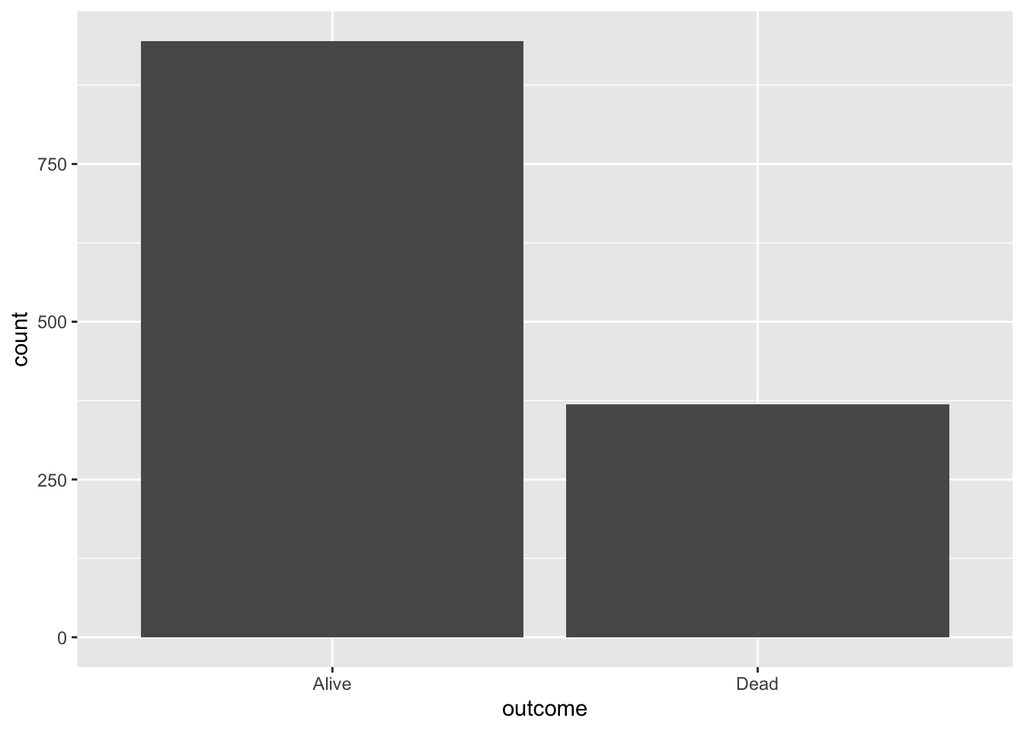

```r
ggplot(data=Whickham, aes(x=outcome)) +
  geom_bar(stat="count")
```

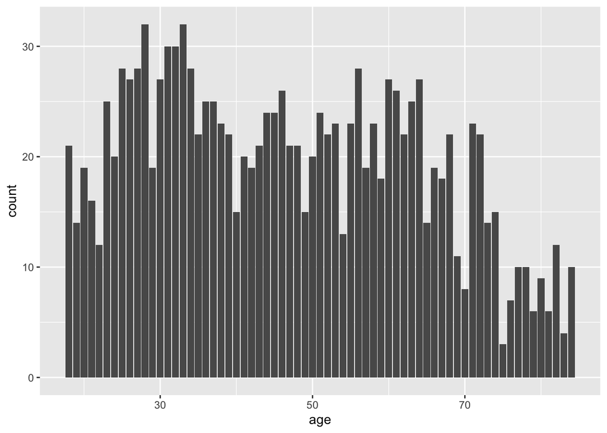

```r
ggplot(data=Whickham, aes(x=age)) +
  geom_bar(stat="count")
```

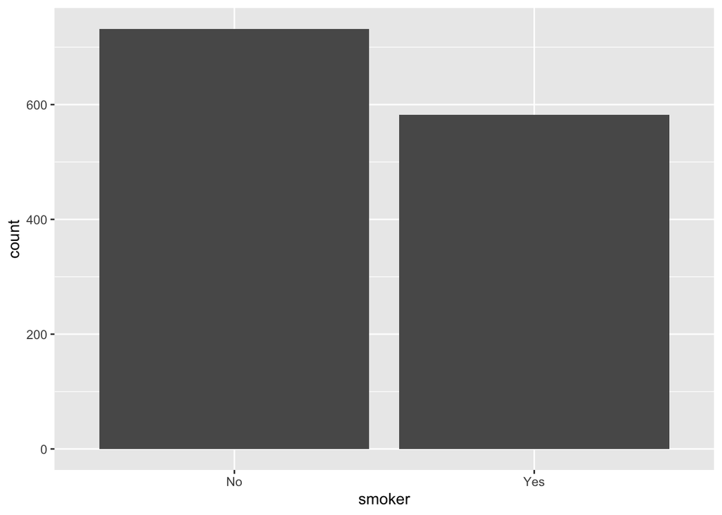

```r
ggplot(data=Whickham, aes(x=smoker)) +
  geom_bar(stat="count")
```

###Exercise 4 ###What would you expect the relationship between smoking status and health outcome to be? ###The more people smoke, less likely they’ll be alive, inverse relationship between smoking status and health outcome

###Exercise 5

```r
view(Whickham)
Whickham %>%
  count(smoker,outcome) %>%
  group_by(smoker) %>%
  mutate(prop_death = n / sum(n)) %>%
  ungroup()
```

```
## # A tibble: 4 x 4
##   smoker outcome     n prop_death
##   <fct>  <fct>   <int>      <dbl>
## 1 No     Alive     502      0.686
## 2 No     Dead      230      0.314
## 3 Yes    Alive     443      0.761
## 4 Yes    Dead      139      0.239
```

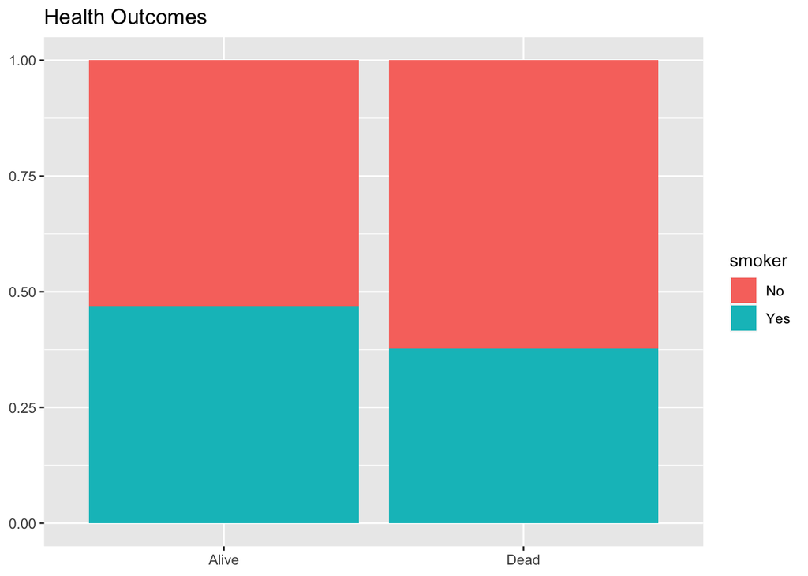

```r
ggplot(Whickham, aes(x = outcome,
                     fill = smoker)) +
  geom_bar(position = "fill") +
  labs(title = "Health Outcomes",
       y = NULL, x = NULL)
```

###I expected the disparity to be much larger, so more people who smoke to be dead vs. alive. ###Exercise 6

```r
Whickham<- Whickham %>%
  mutate(age_cat= case_when(age <= "44" ~ "18-44",
                             age > "44" & age <= "64" ~ "45-64",
                             age > "64" ~ "65+"))
Whickham<- Whickham %>%
  mutate(outcome_smoker= case_when(outcome == "Alive" & smoker == "Yes" ~ "Smoker_n_Alive",
                                   outcome == "Alive" & smoker == "No" ~ "Nonsmoker_n_Alive",
                                   outcome == "Dead" & smoker == "Yes" ~ "Smoker_n_Dead",
                                   outcome == "Dead" & smoker == "No" ~ "Nonsmoker_n_Alive"))
view(Whickham)
```

###Exercise 7

```r
Whickham %>%
  count(smoker, age_cat, outcome)
```

```
##    smoker age_cat outcome   n
## 1      No   18-44   Alive 327
## 2      No   18-44    Dead  12
## 3      No   45-64   Alive 147
## 4      No   45-64    Dead  53
## 5      No     65+   Alive  28
## 6      No     65+    Dead 165
## 7     Yes   18-44   Alive 270
## 8     Yes   18-44    Dead  15
## 9     Yes   45-64   Alive 167
## 10    Yes   45-64    Dead  80
## 11    Yes     65+   Alive   6
## 12    Yes     65+    Dead  44
```

```r
Whickham %>%
  count(smoker, outcome)
```

```
##   smoker outcome   n
## 1     No   Alive 502
## 2     No    Dead 230
## 3    Yes   Alive 443
## 4    Yes    Dead 139
```

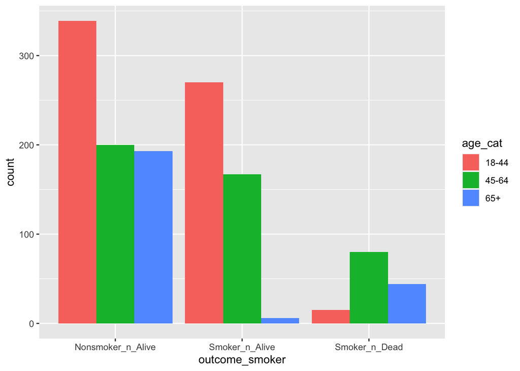

```r
ggplot(Whickham, aes(x = outcome_smoker,
                     fill = age_cat)) +
  geom_bar(stat ="count", position = position_dodge())
```

```r
  labs(title = "Health Outcomes",
       y = NULL, x = NULL)
```

```
## $y
## NULL
##
## $x
## NULL
##
## $title
## [1] "Health Outcomes"
##
## attr(,"class")
## [1] "labels"
```